# MTN Telco Custormer Rention analysis

## 1. Defining the Question

### a) Specifying the Data Analysis Question

The management would like to get your assistance in understanding the current subscribed customers. Your recommendations informed by your analysis will help them make informed decisions on effective customer retention programs.

### b) Defining the Metric for Success

The solution will have satisfied the research question when you can identify the factors that contribute to customer churn.

### c) Understanding the context

MTN Telecom offers mobile and internet services to its customers. These services include phone, multiple lines, internet, online security, online backup, device protection, tech support, and streaming TV and movies.

You have been provided with the current customer data. Since you will be working towards a descriptive report than a predictive one, you decide to think critically of the kind of questions that would help you craft customer retention programs. You then later use the given data set to answer your questions but before you start, you reading, explore, clean and visualise your dataset.

### d) Recording the Experimental Design

The steps to be taken include: 1. Load dataset and preview its summarized information to get a feel of what you will be working with. 2. Carry out data cleaning. 3. Carry out data analysis. 4. Interpret results. 5. Provide recommendations based on results of analysis. 6. Challenge your solution.

### e) Data Relevance

For now, the data we have contains churn data which will be critical for our research specific analysis.

## 2. Data Cleaning & Preparation

```r
#loading libraries
library(tidyverse)
#loading data
df_mtn <- read_csv("https://bit.ly/2ZlpzjF")
df_mtn
```

| customerID | GENDER | SeniorCitizen | PARTNER | Dependents | tenure | PhoneService | MultipleLines | InternetService | OnlineSecurity | OnlineBackup | DeviceProtection | TECHSUPPORT | StreamingTV | StreamingMovies | Contract | PaperlessBilling | PaymentMethod | MonthlyCharges | TotalCharges | Churn |
| --- | --- | --- | --- | --- | --- | --- | --- | --- | --- | --- | --- | --- | --- | --- | --- | --- | --- | --- | --- | --- |
| 7590-VHVEG | Female | 0 | Yes | No | 1 | No | No phone service | DSL | No | Yes | No | No | No | No | Month-to-month | Yes | Electronic check | 29.85 | 29.85 | No |
| 5575-GNVDE | Male | 0 | No | No | 34 | Yes | No | DSL | Yes | No | Yes | No | No | No | One year | No | Mailed check | 56.95 | 1889.50 | No |
| 3668-QPYBK | Male | 0 | No | No | 2 | Yes | No | DSL | Yes | Yes | No | No | No | No | Month-to-month | Yes | Mailed check | 53.85 | 108.15 | Yes |
| 7795-CFOCW | Male | 0 | No | No | 45 | No | No phone service | DSL | Yes | No | Yes | Yes | No | No | One year | No | Bank transfer (automatic) | 42.30 | 1840.75 | No |
| 9237-HQITU | Female | 0 | No | No | 2 | Yes | No | Fiber optic | No | No | No | No | No | No | Month-to-month | Yes | Electronic check | 70.70 | 151.65 | Yes |
| 9305-CDSKC | Female | 0 | No | No | 8 | Yes | Yes | Fiber optic | No | No | Yes | No | Yes | Yes | Month-to-month | Yes | Electronic check | 99.65 | 820.50 | Yes |
| 1452-KIOVK | Male | 0 | No | Yes | 22 | Yes | Yes | Fiber optic | No | Yes | No | No | Yes | No | Month-to-month | Yes | Credit card (automatic) | 89.10 | 1949.40 | No |
| 6713-OKOMC | Female | 0 | No | No | 10 | No | No phone service | DSL | Yes | No | No | No | No | No | Month-to-month | No | Mailed check | 29.75 | 301.90 | No |
| 7892-POOKP | Female | 0 | Yes | No | 28 | Yes | Yes | Fiber optic | No | No | Yes | Yes | Yes | Yes | Month-to-month | Yes | Electronic check | 104.80 | 3046.05 | Yes |
| 6388-TABGU | Male | 0 | No | Yes | 62 | Yes | No | DSL | Yes | Yes | No | No | No | No | One year | No | Bank transfer (automatic) | 56.15 | 3487.95 | No |

[output cut: 7040 more lines]

```r
#data dimension
dim(df_mtn)
```

```
## [1] 7050   21
```

This data set has 7,050 records and 21 variables.

```r
#remove duplicates
df_mtn <- distinct(df_mtn)
dim(df_mtn)
```

```
## [1] 7043   21
```

7 duplicates values were found in the dataset which were dropped.

```r
#drop missing value
df_mtn <- na.omit(df_mtn)
dim(df_mtn)
```

```
## [1] 7003   21
```

40 missing values were dropped, which isn’t a big loss.

```r
#properly formatting columns to lowercase
names(df_mtn) <- tolower(names(df_mtn))
names(df_mtn)
```

```
##  [1] "customerid"       "gender"           "seniorcitizen"    "partner"
##  [5] "dependents"       "tenure"           "phoneservice"     "multiplelines"
##  [9] "internetservice"  "onlinesecurity"   "onlinebackup"     "deviceprotection"
## [13] "techsupport"      "streamingtv"      "streamingmovies"  "contract"
## [17] "paperlessbilling" "paymentmethod"    "monthlycharges"   "totalcharges"
## [21] "churn"
```

```r
#previewing the number of unique values
sample_n(unique(df_mtn), 7)
```

| customerid | gender | seniorcitizen | partner | dependents | tenure | phoneservice | multiplelines | internetservice | onlinesecurity | onlinebackup | deviceprotection | techsupport | streamingtv | streamingmovies | contract | paperlessbilling | paymentmethod | monthlycharges | totalcharges | churn |
| --- | --- | --- | --- | --- | --- | --- | --- | --- | --- | --- | --- | --- | --- | --- | --- | --- | --- | --- | --- | --- |
| 9227-LUNBG | Female | 0 | No | No | 1 | No | No phone service | DSL | No | No | No | No | No | No | Month-to-month | No | Electronic check | 24.60 | 24.60 | Yes |
| 4735-BJKOU | Female | 0 | No | No | 40 | Yes | No | No | No internet service | No internet service | No internet service | No internet service | No internet service | No internet service | Two year | No | Mailed check | 20.15 | 804.85 | No |
| 8739-XNIKG | Female | 0 | No | No | 5 | Yes | Yes | Fiber optic | No | No | No | No | Yes | No | Month-to-month | Yes | Electronic check | 84.00 | 424.75 | No |
| 5827-MWCZK | Male | 0 | Yes | Yes | 56 | Yes | Yes | Fiber optic | No | Yes | No | Yes | Yes | No | Month-to-month | Yes | Credit card (automatic) | 96.95 | 5432.20 | No |
| 4081-DYXAV | Female | 0 | No | No | 19 | No | No phone service | DSL | No | No | No | No | Yes | Yes | One year | Yes | Credit card (automatic) | 44.85 | 893.55 | Yes |
| 0404-AHASP | Male | 0 | Yes | No | 72 | Yes | No | No | No internet service | No internet service | No internet service | No internet service | No internet service | No internet service | Two year | No | Credit card (automatic) | 19.70 | 1421.90 | No |
| 1591-XWLGB | Female | 0 | Yes | No | 71 | Yes | No | No | No internet service | No internet service | No internet service | No internet service | No internet service | No internet service | Two year | No | Credit card (automatic) | 19.85 | 1379.60 | No |

```r
#checking the datatypes
str(df_mtn)
```

```
## tibble [7,003 × 21] (S3: tbl_df/tbl/data.frame)
##  $ customerid      : chr [1:7003] "7590-VHVEG" "5575-GNVDE" "3668-QPYBK" "7795-CFOCW" ...
##  $ gender          : chr [1:7003] "Female" "Male" "Male" "Male" ...
##  $ seniorcitizen   : num [1:7003] 0 0 0 0 0 0 0 0 0 0 ...
##  $ partner         : chr [1:7003] "Yes" "No" "No" "No" ...
##  $ dependents      : chr [1:7003] "No" "No" "No" "No" ...
##  $ tenure          : num [1:7003] 1 34 2 45 2 8 22 10 28 62 ...
##  $ phoneservice    : chr [1:7003] "No" "Yes" "Yes" "No" ...
##  $ multiplelines   : chr [1:7003] "No phone service" "No" "No" "No phone service" ...
##  $ internetservice : chr [1:7003] "DSL" "DSL" "DSL" "DSL" ...
##  $ onlinesecurity  : chr [1:7003] "No" "Yes" "Yes" "Yes" ...
##  $ onlinebackup    : chr [1:7003] "Yes" "No" "Yes" "No" ...
##  $ deviceprotection: chr [1:7003] "No" "Yes" "No" "Yes" ...
##  $ techsupport     : chr [1:7003] "No" "No" "No" "Yes" ...
##  $ streamingtv     : chr [1:7003] "No" "No" "No" "No" ...
##  $ streamingmovies : chr [1:7003] "No" "No" "No" "No" ...
##  $ contract        : chr [1:7003] "Month-to-month" "One year" "Month-to-month" "One year" ...
##  $ paperlessbilling: chr [1:7003] "Yes" "No" "Yes" "No" ...
##  $ paymentmethod   : chr [1:7003] "Electronic check" "Mailed check" "Mailed check" "Bank transfer (automatic)" ...
##  $ monthlycharges  : num [1:7003] 29.9 57 53.9 42.3 70.7 ...
##  $ totalcharges    : num [1:7003] 29.9 1889.5 108.2 1840.8 151.7 ...
##  $ churn           : chr [1:7003] "No" "No" "Yes" "No" ...
##  - attr(*, "na.action")= 'omit' Named int [1:40] 489 754 937 960 961 976 983 1083 1188 1199 ...
##   ..- attr(*, "names")= chr [1:40] "489" "754" "937" "960" ...
```

```r
# check unique seniors
distinct_senior = unique(df_mtn$seniorcitizen)
distinct_senior
```

```
## [1] 0 1
```

```r
# check unique seniors
distinct_payment = unique(df_mtn$paymentmethod)
distinct_payment
```

```
## [1] "Electronic check"          "Mailed check"
## [3] "Bank transfer (automatic)" "Credit card (automatic)"
## [5] "Mailed checkkk"            "Electronic checkk"
```

We can see that some variables aren’t quite right when it comes to their unique values. For example: * ‘seniorcitizen’ should be a boolean object (Yes/No), not a float binary (0.0/0.1) * ‘paymentmethod’ has values with spelling errors such as “Mailed checkkk” and “Electronic chekk”, which created duplicates

```r
# resolve unique seniors
df_mtn$seniorcitizen <- replace(df_mtn$seniorcitizen,df_mtn$seniorcitizen ==0,"No")
df_mtn$seniorcitizen <- replace(df_mtn$seniorcitizen,df_mtn$seniorcitizen ==1,"Yes")
unique(df_mtn$seniorcitizen)
```

```
## [1] "No"  "Yes"
```

```r
# resolve payment methods
df_mtn$paymentmethod <- replace(df_mtn$paymentmethod,df_mtn$paymentmethod =="Mailed checkkk","Mailed check")
df_mtn$paymentmethod <- replace(df_mtn$paymentmethod,df_mtn$paymentmethod =="Electronic checkk","Electronic check")
unique(df_mtn$paymentmethod)
```

```
## [1] "Electronic check"          "Mailed check"
## [3] "Bank transfer (automatic)" "Credit card (automatic)"
```

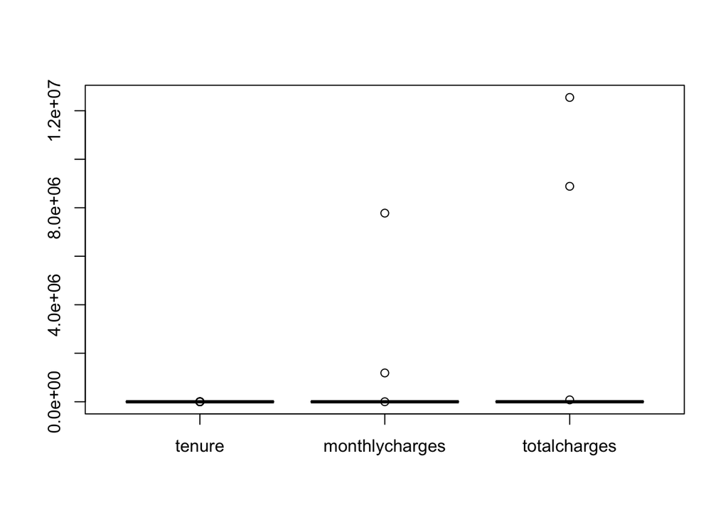

```r
# do a box plot on outliers
boxplot(select(df_mtn, tenure, monthlycharges, totalcharges))
```

We can see that there are several outliers in the ‘tenure’, ‘monthly_charges’, and ‘total_charges’ variables. We can remove them using the IQR method.

```r
#find Q1, Q3, and interquartile range for values in column tenure
quartiles <- quantile(df_mtn$tenure, probs=c(.25, .75), na.rm = FALSE)
IQR <- IQR(df_mtn$tenure)

Lower <- quartiles[1] - 1.5*IQR
Upper <- quartiles[2] + 1.5*IQR

#only keep rows in dataframe that have values within 1.5*IQR of Q1 and Q3
data_no_outlier <- subset(df_mtn, df_mtn$tenure > Lower & df_mtn$tenure < Upper)

#view row and column count of new data frame
dim(data_no_outlier)
```

```
## [1] 6996   21
```

## 3. Data Analysis

### Research-specific Analysis

What percentage of customers from our dataset churned?

```r
# count then perform percentage

df_mtn %>%
  count(churn) %>%
    mutate(percent = n/sum(n))
```

| churn | n | percent |
| --- | --- | --- |
| No | 5140 | 0.7339712 |
| Yes | 1863 | 0.2660288 |

26.6% Churned

What is the gender role in churn?

```r
# count then perform percentage

df_mtn %>%
  count(churn, gender) %>%
    mutate(percent = n/sum(n))
```

| churn | gender | n | percent |
| --- | --- | --- | --- |
| No | Female | 2527 | 0.3608454 |
| No | Male | 2613 | 0.3731258 |
| Yes | Female | 936 | 0.1336570 |
| Yes | Male | 927 | 0.1323718 |

Female and male have 13.36% and 13.23% respectively, indicating gender doesn’t influence churn

Does senior citizen influence churn?

```r
# count then perform percentage

df_mtn %>%
  count(churn, seniorcitizen) %>%
    mutate(percent = n/sum(n))
```

| churn | seniorcitizen | n | percent |
| --- | --- | --- | --- |
| No | No | 4477 | 0.63929744 |
| No | Yes | 663 | 0.09467371 |
| Yes | No | 1389 | 0.19834357 |
| Yes | Yes | 474 | 0.06768528 |

Does having a partner influence churn?

```r
# count then perform percentage

df_mtn %>%
  count(churn, partner) %>%
    mutate(percent = n/sum(n))
```

| churn | partner | n | percent |
| --- | --- | --- | --- |
| No | No | 2428 | 0.3467086 |
| No | Yes | 2712 | 0.3872626 |
| Yes | No | 1196 | 0.1707839 |
| Yes | Yes | 667 | 0.0952449 |

Customers with partners have lower churn 9.5% compared to those without 17.07%

Does having a dependents influence churn?

```r
# count then perform percentage

df_mtn %>%
  count(churn, dependents) %>%
    mutate(percent = n/sum(n))
```

| churn | dependents | n | percent |
| --- | --- | --- | --- |
| No | No | 3374 | 0.48179352 |
| No | Yes | 1766 | 0.25217764 |
| Yes | No | 1537 | 0.21947737 |
| Yes | Yes | 326 | 0.04655148 |

Customers with dependents have lower churn 4.6% compared to those without 21.94%

Does having a phone service influence churn?

```r
# count then perform percentage

df_mtn %>%
  count(churn, phoneservice) %>%
    mutate(percent = n/sum(n))
```

| churn | phoneservice | n | percent |
| --- | --- | --- | --- |
| No | No | 508 | 0.07254034 |
| No | Yes | 4632 | 0.66143082 |
| Yes | No | 170 | 0.02427531 |
| Yes | Yes | 1693 | 0.24175353 |

Customers with phone service have a high churn 24.17% compared to those without 2.4%

Does having multiple lines influence churn?

```r
# count then perform percentage

df_mtn %>%
  count(churn, multiplelines) %>%
    mutate(percent = n/sum(n))
```

| churn | multiplelines | n | percent |
| --- | --- | --- | --- |
| No | No | 2524 | 0.36041696 |
| No | No phone service | 508 | 0.07254034 |
| No | Yes | 2108 | 0.30101385 |
| Yes | No | 848 | 0.12109096 |
| Yes | No phone service | 170 | 0.02427531 |
| Yes | Yes | 845 | 0.12066257 |

There is no significant difference for the customers who have multiple lines while those customers without no phone service their churn is lower 2.4%.

Does having internet service influence churn?

```r
# count then perform percentage

df_mtn %>%
  count(churn, internetservice) %>%
    mutate(percent = n/sum(n))
```

| churn | internetservice | n | percent |
| --- | --- | --- | --- |
| No | DSL | 1948 | 0.27816650 |
| No | Fiber optic | 1793 | 0.25603313 |
| No | No | 1399 | 0.19977153 |
| Yes | DSL | 459 | 0.06554334 |
| Yes | Fiber optic | 1291 | 0.18434956 |
| Yes | No | 113 | 0.01613594 |

Fiber optic customers have the highest churn rate of 18.43%

Does having online security influence churn?

```r
# count then perform percentage

df_mtn %>%
  count(churn, onlinesecurity) %>%
    mutate(percent = n/sum(n))
```

| churn | onlinesecurity | n | percent |
| --- | --- | --- | --- |
| No | No | 2028 | 0.28959018 |
| No | No internet service | 1399 | 0.19977153 |
| No | Yes | 1713 | 0.24460945 |
| Yes | No | 1457 | 0.20805369 |
| Yes | No internet service | 113 | 0.01613594 |
| Yes | Yes | 293 | 0.04183921 |

Customers without online security have the highest churn rate of 20.8%

Does having online backup influence churn?

```r
# count then perform percentage

df_mtn %>%
  count(churn, onlinebackup) %>%
    mutate(percent = n/sum(n))
```

| churn | onlinebackup | n | percent |
| --- | --- | --- | --- |
| No | No | 1844 | 0.26331572 |
| No | No internet service | 1399 | 0.19977153 |
| No | Yes | 1897 | 0.27088391 |
| Yes | No | 1227 | 0.17521062 |
| Yes | No internet service | 113 | 0.01613594 |
| Yes | Yes | 523 | 0.07468228 |

Does having device protection influence churn?

```r
# count then perform percentage

df_mtn %>%
  count(churn, deviceprotection) %>%
    mutate(percent = n/sum(n))
```

| churn | deviceprotection | n | percent |
| --- | --- | --- | --- |
| No | No | 1874 | 0.26759960 |
| No | No internet service | 1399 | 0.19977153 |
| No | Yes | 1867 | 0.26660003 |
| Yes | No | 1206 | 0.17221191 |
| Yes | No internet service | 113 | 0.01613594 |
| Yes | Yes | 544 | 0.07768099 |

Customers without device protection have the highest churn rate of 17.22%

Does having tech support influence churn?

```r
# count then perform percentage

df_mtn %>%
  count(churn, techsupport) %>%
    mutate(percent = n/sum(n))
```

| churn | techsupport | n | percent |
| --- | --- | --- | --- |
| No | No | 2017 | 0.28801942 |
| No | No internet service | 1399 | 0.19977153 |
| No | Yes | 1724 | 0.24618021 |
| Yes | No | 1442 | 0.20591175 |
| Yes | No internet service | 113 | 0.01613594 |
| Yes | Yes | 308 | 0.04398115 |

Customers that don’t get tech support have the highest churn rate 20.59%

Does monthly in respect to payment method influence churn?

```r
# group by then perform summary

df_mtn %>%
  group_by(churn, paymentmethod) %>%
    summarise(monthlycharges = sum(monthlycharges)) %>% arrange(desc(monthlycharges))
```

| churn | paymentmethod | monthlycharges |
| --- | --- | --- |
| No | Credit card (automatic) | 7860792.35 |
| No | Bank transfer (automatic) | 1271052.90 |
| No | Electronic check | 95572.65 |
| Yes | Electronic check | 83919.40 |
| No | Mailed check | 54099.45 |
| Yes | Bank transfer (automatic) | 19992.05 |
| Yes | Credit card (automatic) | 17866.30 |
| Yes | Mailed check | 16803.60 |

Electronic check payment method seems to have the highest churn followed by Bank transfer(automatic), Credit card (automatic) and Mailed check.

Does total charges in resepect to payment method influence churn?

```r
# count then perform percentage

df_mtn %>%
  group_by(churn, paymentmethod) %>%
    summarise(totalcharges = sum(totalcharges)) %>% arrange(desc(totalcharges))
```

| churn | paymentmethod | totalcharges |
| --- | --- | --- |
| Yes | Electronic check | 14100291.1 |
| Yes | Bank transfer (automatic) | 9463834.8 |
| No | Credit card (automatic) | 4189729.0 |
| No | Bank transfer (automatic) | 4146584.6 |
| No | Electronic check | 3358249.1 |
| No | Mailed check | 1519439.4 |
| Yes | Credit card (automatic) | 542776.7 |
| Yes | Mailed check | 164478.9 |

Electronic check and Bank transfer (automatic) payment methods even though they have the highest billing charges they top the payment methods that was used by the churned customers.

## 5. Recommendations

In order to create an effective customer retention program, management should take the following measures:

- Focus more on meeting the needs of non-senior citizens.
- Focus more on having customers that have partners and/or dependents since these people are less likely to churn. Alternatively, management can come up with services specifically designed for customers without partners and/or dependents. This would require additional research.
- Focus on providing more online security services to customers. *Encourage customers to user Credit card as payment method. More research is required to understand why Electronic check has the highest churn rate.*
- Focus on marketing more on internet services to address the significant number of customers with no internet service.
- Focus on providing device protection services to customers
- Focus on improving customer service in respect to tech support.

##6. Challenging your Solution

### a). Did we have the right data? Do we need other data to answer our question?

s far as I can tell, we had the right data. However, more data is still needed, particularly those with more customers who churned so we can have a better understanding of why they might have churned.

### b). Did we have the right question?

Yes, we did.